# Assignment 3 - Classification

# Data set description

The data set we chose to use for this assignment is the occupation detection dataset which can be obtained at https://archive.ics.uci.edu/ml/datasets/Occupancy+Detection+. There are 7 columns in the data set which are:

1. Date - Consists of the date and time of which the data was recorded
2. Temperature - Temperature of the room. Measured in Celsius.
3. Humidity - Relative humidity in %
4. Light - Light intensity of the room. Measured in Lux.
5. CO2 - Amount of carbon dioxide of the room. Measured in ppm.
6. Humidity Ratio - Derived attribute from Temperature and Humidity. Unit is kgwater-vapor/kg-air
7. Occupancy (Class Label) - Labels the room on whether it is unoccupied (0) or occupied (1)

# Loading all the libraries needed

```r
library(ggplot2)
library(gridExtra)
library(Hmisc)
library(corrplot)
library(arules)
library(caret)                    #Confusion Matrix
library(tree)                     #Decision Tree
library(e1071)                    #Naive Bayes
library(neuralnet)                #Neural Network
```

# Reading in the data set

```r
#Read in the all the data sets and check its variables
df <- read.csv('datatraining.txt', header = TRUE, sep = ',')
dfTest1 <- read.csv('datatest.txt', header = TRUE, sep = ',')
dfTest2 <- read.csv('datatest2.txt', header = TRUE, sep = ',')
str(df)
```

```
## 'data.frame':    8143 obs. of  7 variables:
##  $ date         : Factor w/ 8143 levels "2015-02-04 17:51:00",..: 1 2 3 4 5 6 7 8 9 10 ...
##  $ Temperature  : num  23.2 23.1 23.1 23.1 23.1 ...
##  $ Humidity     : num  27.3 27.3 27.2 27.2 27.2 ...
##  $ Light        : num  426 430 426 426 426 ...
##  $ CO2          : num  721 714 714 708 704 ...
##  $ HumidityRatio: num  0.00479 0.00478 0.00478 0.00477 0.00476 ...
##  $ Occupancy    : int  1 1 1 1 1 1 1 1 1 1 ...
```

# Preprocessing Part 1

Convert the time values in Date attribute to an hourly fashion. After that, it is coverted to POSIXct format. Besides that, we are also going to convert Occupancy into factors.

```r
df$date <- as.POSIXct(strptime(df$date, "%Y-%m-%d %H:%M:%S"))
df$date <- cut(df$date, breaks = "hour")
df$Occupancy <- as.factor(df$Occupancy)

dfTest1$date <- as.POSIXct(strptime(dfTest1$date, "%Y-%m-%d %H:%M:%S"))
dfTest1$date <- cut(dfTest1$date, breaks = "hour")
dfTest1$Occupancy <- as.factor(dfTest1$Occupancy)

dfTest2$date <- as.POSIXct(strptime(dfTest2$date, "%Y-%m-%d %H:%M:%S"))
dfTest2$date <- cut(dfTest2$date, breaks = "hour")
dfTest2$Occupancy <- as.factor(dfTest2$Occupancy)
```

Splitting the Date attribute to two different attributes: Date and Time.

```r
datetimesplit <- data.frame(do.call(rbind, strsplit(as.vector(df$date), split = " ")))
df <- cbind(datetimesplit, df$Temperature, df$Humidity, df$Light, df$CO2, df$HumidityRatio, df$Occupancy)
names(df) <- c("Date", "Time", "Temperature", "Humidity", "Light", "CO2", "HumidityRatio", "Occupancy")

datetimesplit2 <- data.frame(do.call(rbind, strsplit(as.vector(dfTest1$date), split = " ")))
dfTest1 <- cbind(datetimesplit2, dfTest1$Temperature, dfTest1$Humidity, dfTest1$Light, dfTest1$CO2, dfTest1$HumidityRatio, dfTest1$Occupancy)
names(dfTest1) <- c("Date", "Time", "Temperature", "Humidity", "Light", "CO2", "HumidityRatio", "Occupancy")

datetimesplit3 <- data.frame(do.call(rbind, strsplit(as.vector(dfTest2$date), split = " ")))
dfTest2 <- cbind(datetimesplit3, dfTest2$Temperature, dfTest2$Humidity, dfTest2$Light, dfTest2$CO2, dfTest2$HumidityRatio, dfTest2$Occupancy)
names(dfTest2) <- c("Date", "Time", "Temperature", "Humidity", "Light", "CO2", "HumidityRatio", "Occupancy")
```

Check if the attributes are in the format we want it to be in.

```r
str(df)
```

```
## 'data.frame':    8143 obs. of  8 variables:
##  $ Date         : Factor w/ 7 levels "2015-02-04","2015-02-05",..: 1 1 1 1 1 1 1 1 1 1 ...
##  $ Time         : Factor w/ 24 levels "00:00:00","01:00:00",..: 18 18 18 18 18 18 18 18 18 19 ...
##  $ Temperature  : num  23.2 23.1 23.1 23.1 23.1 ...
##  $ Humidity     : num  27.3 27.3 27.2 27.2 27.2 ...
##  $ Light        : num  426 430 426 426 426 ...
##  $ CO2          : num  721 714 714 708 704 ...
##  $ HumidityRatio: num  0.00479 0.00478 0.00478 0.00477 0.00476 ...
##  $ Occupancy    : Factor w/ 2 levels "0","1": 2 2 2 2 2 2 2 2 2 2 ...
```

Check for special values in data set.

```r
is.special <- function(x){
  if (is.numeric(x)) !is.finite(x) else is.na(x)
}
which((data.frame(sapply(df, is.special))) == TRUE)
```

```
## integer(0)
```

Looks like there are no special values found in training set

# Exploratory Data Analysis

First, we want to check how many observations belong to each class

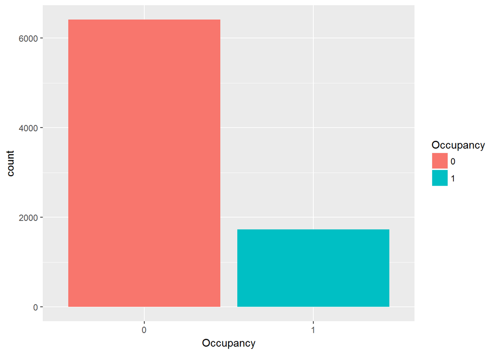

```r
#Bar chart
ggplot(data=df, aes(x=Occupancy, fill=Occupancy)) + geom_bar(stat="count")
```

```r
#Exact values
summary(df$Occupancy)
```

```
##    0    1
## 6414 1729
```

We can see that majority of the observations belong to the 0 class. This means that our data is highly skewed towards the 0 class. Now we want to check for outliers. We will do so using boxplots.

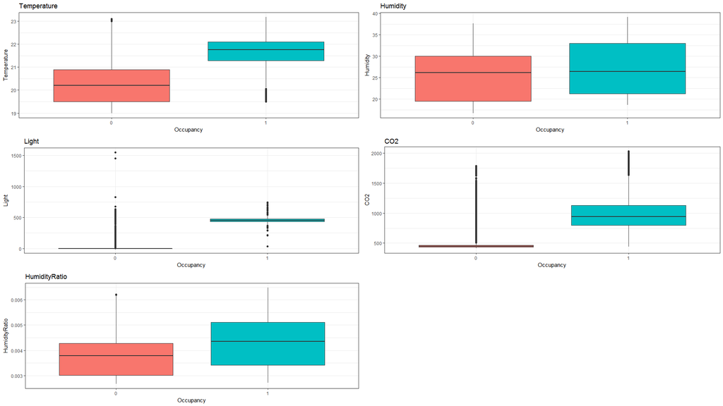

```r
boxplot1 <- ggplot(df, aes(x=Occupancy, y=Temperature, fill=Occupancy))+
  geom_boxplot(aes(group = Occupancy))+
  theme_bw()+
  xlab("Occupancy")+
  ylab("Temperature")+
  ggtitle("Temperature") + theme(legend.position = "none")

boxplot2 <- ggplot(df, aes(x=Occupancy, y=Humidity, fill=Occupancy))+
  geom_boxplot(aes(group = Occupancy))+
  theme_bw()+
  xlab("Occupancy")+
  ylab("Humidity")+
  ggtitle("Humidity") + theme(legend.position = "none")

boxplot3 <- ggplot(df, aes(x=Occupancy, y=Light, fill=Occupancy))+
  geom_boxplot(aes(group = Occupancy))+
  theme_bw()+
  xlab("Occupancy")+
  ylab("Light")+
  ggtitle("Light") + theme(legend.position = "none")

boxplot4 <- ggplot(df, aes(x=Occupancy, y=CO2, fill=Occupancy))+
  geom_boxplot(aes(group = Occupancy))+
  theme_bw()+
  xlab("Occupancy")+
  ylab("CO2")+
  ggtitle("CO2") + theme(legend.position = "none")

boxplot5 <- ggplot(df, aes(x=Occupancy, y=HumidityRatio, fill=Occupancy))+
  geom_boxplot(aes(group = Occupancy))+
  theme_bw()+
  xlab("Occupancy")+
  ylab("HumidityRatio")+
  ggtitle("HumidityRatio") + theme(legend.position = "none")

grid.arrange(boxplot1, boxplot2, boxplot3, boxplot4, boxplot5, ncol=2, nrow=3)
```

Humidity and HumidityRatio has very little to no outliers. Instead, there are more outliers in Temperature, Light and CO2. We do not want to remove outliers especially for when the Occupancy is ‘1’ because we only have very little data for that class compared to when the Occupancy is ‘0’. Besides that, outliers may signify something important especially when many of them are grouped together because there may be some hidden meaning behind it which we may not be able to explain with our raw knowledge. To explain the outliers, let us plot histograms and density plots to see the distribution of the data for each of these attributes. We shall start with histograms.

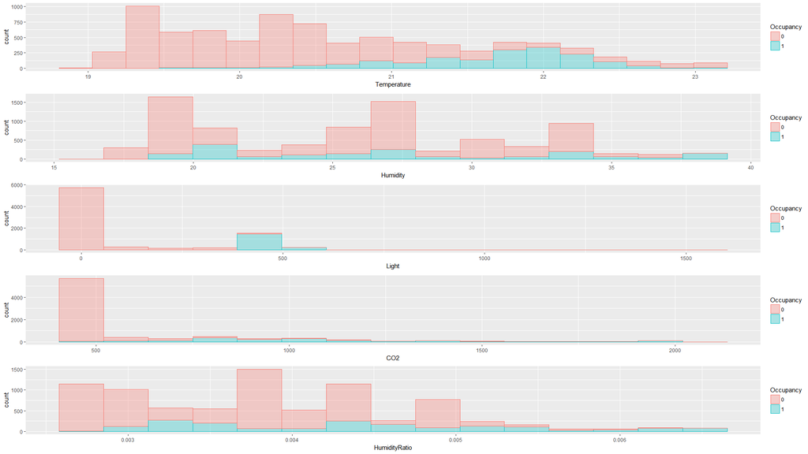

```r
h1 <- ggplot(df, aes(x=Temperature)) + geom_histogram(aes(group=Occupancy, colour=Occupancy, fill=Occupancy), alpha=0.3, bins = 15)
h2 <- ggplot(df, aes(x=Humidity)) + geom_histogram(aes(group=Occupancy, colour=Occupancy, fill=Occupancy), alpha=0.3, bins = 15)
h3 <- ggplot(df, aes(x=Light)) + geom_histogram(aes(group=Occupancy, colour=Occupancy, fill=Occupancy), alpha=0.3, bins = 15)
h4 <- ggplot(df, aes(x=CO2)) + geom_histogram(aes(group=Occupancy, colour=Occupancy, fill=Occupancy), alpha=0.3, bins = 15)
h5 <- ggplot(df, aes(x=HumidityRatio)) + geom_histogram(aes(group=Occupancy, colour=Occupancy, fill=Occupancy), alpha=0.3, bins = 15)

grid.arrange(h1, h2, h3, h4, h5, ncol=1, nrow=5)
```

For Occupancy = ‘1’ in Temperature, we can see that although most of it is >20.5, there is quite a number of them which is <20.5. We think that these outliers are acceptable and can be included in our model.  
For Occupancy = ‘0’ in Light, we can see that the value of the outliers are overlapping with Occupancy = ‘1’. This could mean that maybe the room lights were left on although there is nobody in the room. This could also mean that sunlight is shining into the room but there is nobody in the room. We should not remove these values because when a room is unoccupied in the morning/afternoon, the light intensity will be high eventhough the room is unoccupied. These outliers could be very useful if paired with the ‘Time’ attribute which we have derived. Here is a snapshot of the data set from Excel.

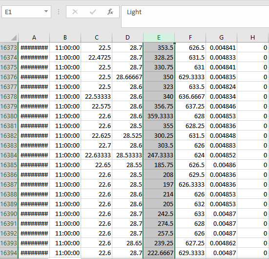

As we can see here, the time is 11 a.m. and Occupancy = ‘0’. The light intensity is high here. This proves that our reasoning is correct where sunlight is shining into the room in the morning. Let us look at another snapshot of the data set from Excel.

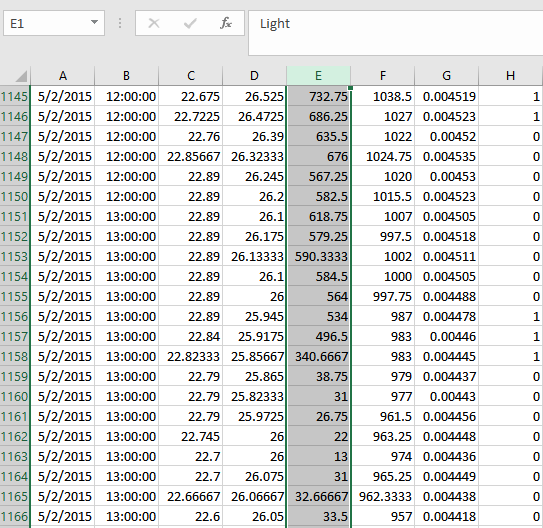

From this snippet, we can see that when the room first changes from state 1 (Occupied) to state 0 (Unoccupied), the light intensity drops very slightly. This may mean that the person who just left the room forgot to turn off the lights. After a while, he/she comes back into the room and turns off the light. Then, the light intensity of the room drops drastically and the room changes state from 1 to 0 again.  
For Occupancy = ‘0’ in CO2, most of the values are also overlapping with Occupancy = ‘1’. What this could mean is that it takes time for the carbon dioxide to disperse after the occupants leave the room. Here is a snapshot of the dataset from Excel.

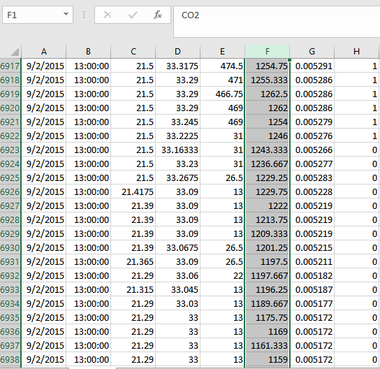

As we can see here, the CO2 concentration in the room is still hovering around the 1200ppm mark and starts to decrease when the room changes its Occupancy state from ‘1’ to ‘0’. Our initial assumption holds true again where CO2 takes some time to disperse when people leave the room.  
Here are the density plots to show how concentrated the data points are with respect to their Occupancy status.

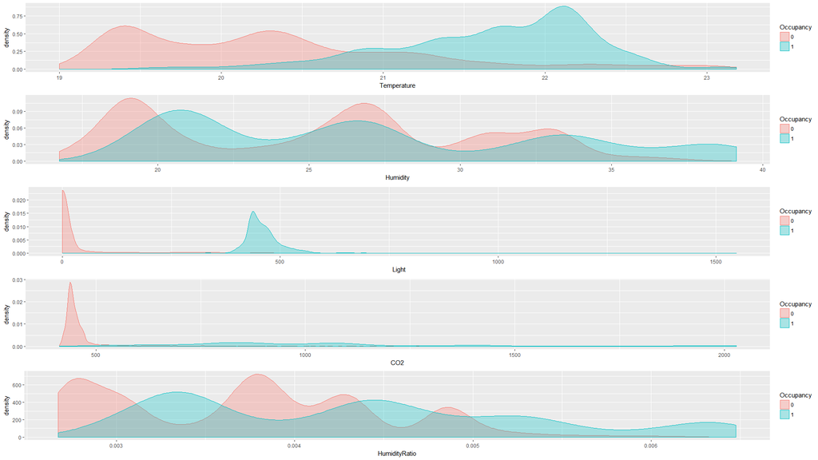

```r
p1 <- ggplot(df, aes(x=Temperature)) + geom_density(aes(group=Occupancy, colour=Occupancy, fill=Occupancy), alpha=0.3)
p2 <- ggplot(df, aes(x=Humidity)) + geom_density(aes(group=Occupancy, colour=Occupancy, fill=Occupancy), alpha=0.3)
p3 <- ggplot(df, aes(x=Light)) + geom_density(aes(group=Occupancy, colour=Occupancy, fill=Occupancy), alpha=0.3)
p4 <- ggplot(df, aes(x=CO2)) + geom_density(aes(group=Occupancy, colour=Occupancy, fill=Occupancy), alpha=0.3)
p5 <- ggplot(df, aes(x=HumidityRatio)) + geom_density(aes(group=Occupancy, colour=Occupancy, fill=Occupancy), alpha=0.3)

grid.arrange(p1, p2, p3, p4, p5, ncol=1, nrow=5)
```

We can see that the outliers in Light and CO2 for Occupancy = ‘0’ is very insignificant. Although it may be in a miniscule amount, we think that it should be included in our model because we know that these outliers happen for a reason and it may prove useful in distinguishing between the two classes.  
Now, we want to see how strongly the variables are correlated to each other.

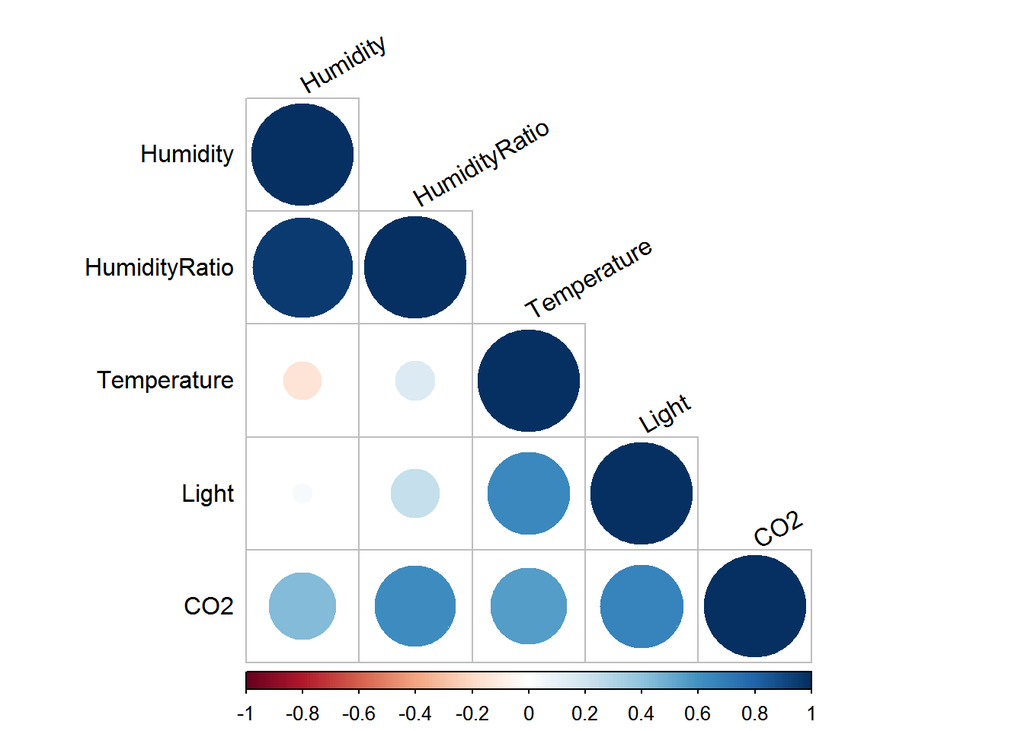

```r
correlation_result<-rcorr(as.matrix(df[3:7]))
corrplot(correlation_result$r, type="lower", order="hclust", tl.col="black", tl.srt=30)
```

We can see a very high correlation between Humidity and HumidityRatio because HumidityRatio is derived from Humidity. However, it is strange that HumidityRatio has a higher correlation with CO2 compared to Temperature eventhough HumidityRatio is also partly derived from Temperature. It is also worth noting that Temperature and Light is also quite highly correlated.

# Preprocessing Part 2 + Splitting data into Train and Test

We will combine all the data set provided into one data frame. We will then create new attributes which are discretized attributes of the existing attributes. We will also create a copy of the big data frame specially for building our neural network model later on. We will perform min-max normalization on the data frame which is to be used for our neural network model. The reason why we chose min-max normalization is because we think that we need to retain the original distribution of the attributes. Z-score normalization does not provide that because our data are not Gaussian distributed. Z-score normalization does not retain the input distribution at the output.

```r
#Combine the data sets into one big data set
df <- rbind(df, dfTest1, dfTest2)

#Dicretize original data frame by equal interval for Naive Bayes
df$TemperatureGroup <- discretize(df$Temperature, categories = 6)
df$HumidityGroup <- discretize(df$Humidity, categories = 6)
df$LightGroup <- discretize(df$Light, categories = 6)
df$CO2Group <- discretize(df$CO2, categories = 6)
df$HumidityRatioGroup <- discretize(df$HumidityRatio, categories = 6)

df$Occupancy <- ifelse(df$Occupancy == 0, "Unoccupied", "Occupied")
df$Occupancy <- as.factor(df$Occupancy)

#Split the data into 70% training and 30% testing
set.seed(100)
train <- sample(1:nrow(df), 14392)
df.train <- df[train,]
df.test <- df[-train,]
Occupancy.test <- df$Occupancy[-train]

# Create Vector of Column Max and Min Values from training set
maxs <- apply(df.train[,3:7], 2, max)
mins <- apply(df.train[,3:7], 2, min)

#Different data frame for neural net. Perform min-max normalization on training data set
dfNN.train <- as.data.frame(scale(df.train[, 3:7], center = mins, scale = maxs - mins))
dfNN.train <- cbind(dfNN.train, df.train$Occupancy)
names(dfNN.train)[6] <- c('Occupancy')
dfNN.train$Unoccupied <- c(dfNN.train$Occupancy == 'Unoccupied')
dfNN.train$Occupied <- c(dfNN.train$Occupancy == 'Occupied')

#Scale the test set with respect to the max and min of the training set because we are trying to predict the values based on the data from the training set. From: http://stackoverflow.com/questions/35532249/mse-in-neuralnet-results-and-roc-curve-of-the-results

#1) You can scale your values (using minmax, for example). But only scale your training data set. Save the parameters used in the scaling process (in minmax they would be the min and max values by which the data is scaled). Only then, you can scale your test data set WITH the min and max values you got from the training data set. Remember, with the test data set you are trying to mimic the process of classifying unseen data. Unseen data is scaled with your scaling parameters from the testing data set.
dfNN.test <- as.data.frame(scale(df.test[, 3:7], center = mins, scale = maxs - mins))
dfNN.test <- cbind(dfNN.test, df.test$Occupancy)
names(dfNN.test)[6] <- c('Occupancy')
dfNN.test$Unoccupied <- c(dfNN.test$Occupancy == 'Unoccupied')
dfNN.test$Occupied <- c(dfNN.test$Occupancy == 'Occupied')
```

# Choice of performance measure

Before doing the modelling and comparing the results of each model, we would like to choose our performance measures. We will be using accuracy, sensitivity (TPR/Recall), and specificity (TNR) to compare the results of our models. We will be displaying the results after each model and the comparison will be done after all the models have been constructed. Our main concern during evaluation of the models will be accuracy because we think that it would be wise to follow Kaggle's way of judging models' performances.

# Decision Tree (Undiscretized Attributes)

For our first model, we want to build a decision tree from the tree library in R using the undiscretized attributes. We chose the attributes: Time, Temperature, Humidity, Light, CO2 and HumidityRatio to be used in our training model. We did not include Date because the data collected is only a few days throughout February. We think that the temperature changes and environmental changes would not be a huge factor because all the data is collected in the same month.

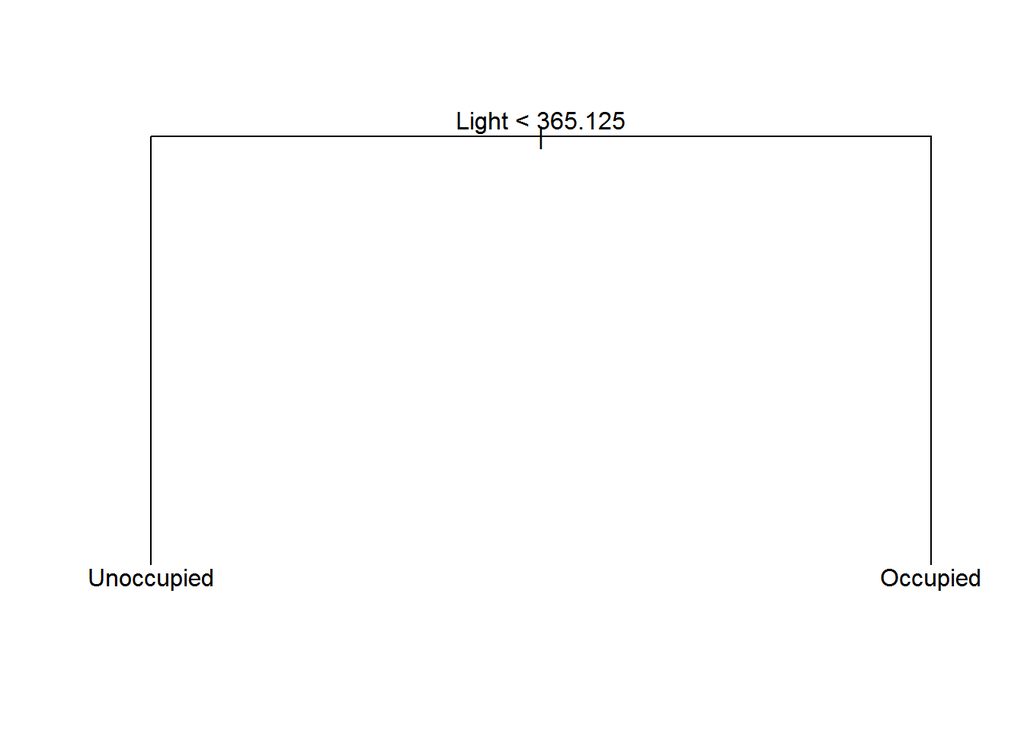

```r
tree_model <- tree(Occupancy~Time+Temperature+Humidity+Light+CO2+HumidityRatio, df.train)
plot(tree_model)
text(tree_model,pretty=0)
```

Looks like the decision tree is only using the Light attribute to perform its classification. Since it has only one branch, we would not need to perform any pruning. Let us check its performance.

```r
tree_pred <- predict(tree_model, df.test, type = "class")
confusionMatrix(tree_pred, Occupancy.test)
```

```
## Confusion Matrix and Statistics
##
##             Reference
## Prediction   Occupied Unoccupied
##   Occupied       1400         63
##   Unoccupied       11       4694
##
##                Accuracy : 0.988
##                  95% CI : (0.985, 0.9906)
##     No Information Rate : 0.7712
##     P-Value [Acc > NIR] : < 2.2e-16
##
##                   Kappa : 0.9664
##  Mcnemar's Test P-Value : 3.055e-09
##
##             Sensitivity : 0.9922
##             Specificity : 0.9868
##          Pos Pred Value : 0.9569
##          Neg Pred Value : 0.9977
##              Prevalence : 0.2288
##          Detection Rate : 0.2270
##    Detection Prevalence : 0.2372
##       Balanced Accuracy : 0.9895
##
##        'Positive' Class : Occupied
##
```

# Decision Tree (Discretized Attributes)

For our second model, we will build a decision tree from the tree library in R using the discretized attributes. The chosen attributes are the same as the first decision tree. The only change is that we are using the discretized attributes instead.

```r
tree_model <- tree(Occupancy~Time+TemperatureGroup+LightGroup+HumidityGroup+CO2Group+HumidityRatioGroup, df.train)
```

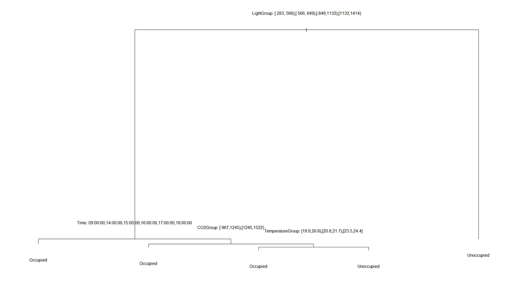

```r
plot(tree_model)
text(tree_model,pretty=0)
```

Let us try to prune the tree.

```r
cv_tree <- cv.tree(tree_model, FUN = prune.misclass)
names(cv_tree)
```

```
## [1] "size"   "dev"    "k"      "method"
```

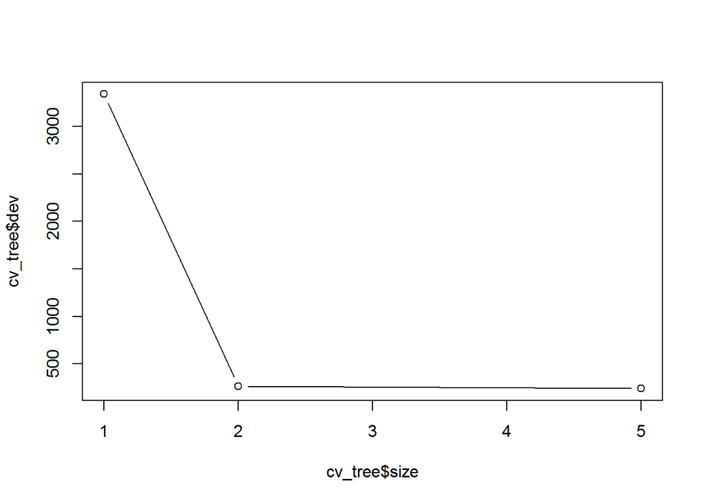

```r
plot(cv_tree$size,cv_tree$dev, type= "b")
```

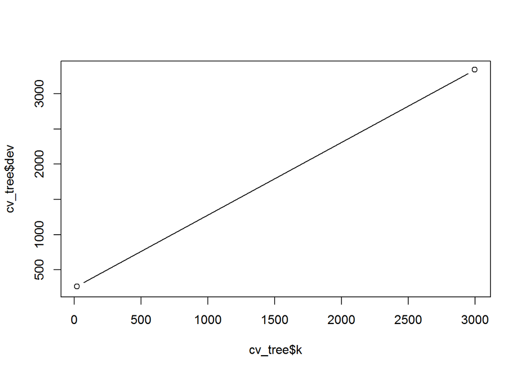

```r
plot(cv_tree$k,cv_tree$dev, type= "b")
```

The tree seems to perform the best at size = 5. However, the error drop from when the tree’s size = 2 to size = 5 is very minimal. We think that a tree of size = 5 is acceptable and that it’s size is not too large. Let us measure its performance.

```r
tree_pred <- predict(tree_model, df.test, type = "class")
confusionMatrix(tree_pred, Occupancy.test)
```

```
## Confusion Matrix and Statistics
##
##             Reference
## Prediction   Occupied Unoccupied
##   Occupied       1347         77
##   Unoccupied       64       4680
##
##                Accuracy : 0.9771
##                  95% CI : (0.9731, 0.9807)
##     No Information Rate : 0.7712
##     P-Value [Acc > NIR] : <2e-16
##
##                   Kappa : 0.9354
##  Mcnemar's Test P-Value : 0.3122
##
##             Sensitivity : 0.9546
##             Specificity : 0.9838
##          Pos Pred Value : 0.9459
##          Neg Pred Value : 0.9865
##              Prevalence : 0.2288
##          Detection Rate : 0.2184
##    Detection Prevalence : 0.2309
##       Balanced Accuracy : 0.9692
##
##        'Positive' Class : Occupied
##
```

# Naive Bayes

For our third model, we want to build a Naive Bayes classifier from the e1071 library. We decided to use the discretized attributes to build this model because of the advice from this link: https://www.quora.com/What-is-the-best-way-to-use-continuous-variables-for-a-naive-bayes-classifier-Do-we-need-to-cluster-them-or-leave-for-self-learning-Pls-help

We will be using the same attributes from the Decision Tree (Discretized Attributes) to build our Naive Bayes model.

```r
NBmodel <- naiveBayes(Occupancy ~ Time+TemperatureGroup+HumidityGroup+LightGroup+CO2Group+HumidityRatioGroup, data = df.train, type = "raw")
predictions <- predict(NBmodel, df.test, type = "class")
confusionMatrix(predictions,Occupancy.test)
```

```
## Confusion Matrix and Statistics
##
##             Reference
## Prediction   Occupied Unoccupied
##   Occupied       1350        152
##   Unoccupied       61       4605
##
##                Accuracy : 0.9655
##                  95% CI : (0.9606, 0.9699)
##     No Information Rate : 0.7712
##     P-Value [Acc > NIR] : < 2.2e-16
##
##                   Kappa : 0.9043
##  Mcnemar's Test P-Value : 6.973e-10
##
##             Sensitivity : 0.9568
##             Specificity : 0.9680
##          Pos Pred Value : 0.8988
##          Neg Pred Value : 0.9869
##              Prevalence : 0.2288
##          Detection Rate : 0.2189
##    Detection Prevalence : 0.2435
##       Balanced Accuracy : 0.9624
##
##        'Positive' Class : Occupied
##
```

# Artificial Neural Network (ANN)

For our last model, we are going to build an ANN model from the neuralnet library. For this, we will be using the separate data set which we have prepared for the neural network. All the continuous attributes have been transformed via min-max normalization previously. However, we cannot use the attribute Time in our ANN model because it is a factor. ANN requires the arguments to be numeric vectors. We will be using three hidden nodes for our ANN.

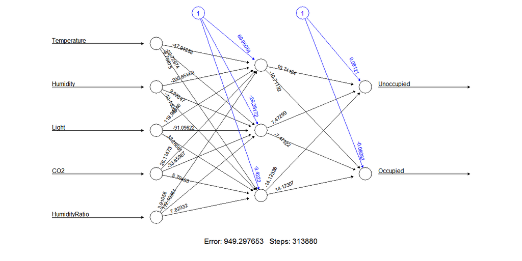

```r
#Building the neural net model. err.fct = "ce" means use cross-entropy for error function. Cross-entropy is better for classification while mean of sum of square errors is better for regression which is what was covered in class.
formula <- Unoccupied+Occupied~Temperature+Humidity+Light+CO2+HumidityRatio
NNmodel <- neuralnet(formula, dfNN.train, hidden=3, err.fct="ce",linear.output=FALSE, stepmax = 1000000)
plot(NNmodel, class = "nn")
```

```r
predict <- compute(NNmodel, dfNN.test[,1:5])
predspp <- factor(c("Unoccupied", "Occupied"))[apply(predict$net.result, MARGIN=1, FUN=which.max)]
confusionMatrix(predspp, dfNN.test$Occupancy)
```

```
## Confusion Matrix and Statistics
##
##             Reference
## Prediction   Occupied Unoccupied
##   Occupied       1401         63
##   Unoccupied       10       4694
##
##                Accuracy : 0.9882
##                  95% CI : (0.9851, 0.9907)
##     No Information Rate : 0.7712
##     P-Value [Acc > NIR] : < 2.2e-16
##
##                   Kappa : 0.9669
##  Mcnemar's Test P-Value : 1.157e-09
##
##             Sensitivity : 0.9929
##             Specificity : 0.9868
##          Pos Pred Value : 0.9570
##          Neg Pred Value : 0.9979
##              Prevalence : 0.2288
##          Detection Rate : 0.2271
##    Detection Prevalence : 0.2374
##       Balanced Accuracy : 0.9898
##
##        'Positive' Class : Occupied
##
```

# Performance Of The Three Classifiers

For the decision tree models, we will only take the one with the highest Accuracy which is the decision tree which was built using the undiscretized attributes.

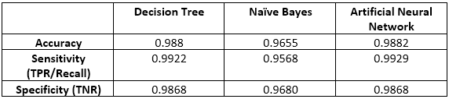

# Explanation On Their Performance

First, let us define what is accuracy, sensitivity (True Positive Rate) and specificity (True Negative Rate).

Accuracy is the simplest one which can be defined as the percentage of predictions that are correctly predicted.

Sensitivity, also known as True Positive Rate (TPR) or Recall, can be defined as the proportion of positives (in our case when Occupancy = ‘Occupied’) that are correctly identified as such. In other words, from all the observations which are labelled as ‘Occupied’, how many observations did your model predict ‘Occupied’ correctly. Sensitivity can be calculated by the equation:

$$\frac{True Positives}{True Positives + False Negatives}$$

Specificity, also known as True Negative Rate (TNR), can be defined as the proportion of negatives (in our case when Occupancy = ‘Unoccupied’) that are correctly identified as such. In other words, from all the observations which are labelled as ‘Unoccupied’, how many observations did your model predict ‘Unoccupied’ correctly. Specificity can be calculated by the equation:

$$\frac{True Negatives}{True Negatives + False Positives}$$

The reason Naive Bayes has the worst results is because it assumes independence between variables. This is not the case for our data set. As explained earlier, when the time of the day is 11 a.m., light intensity will be high eventhough the room is unoccupied. This would mean that the variables are dependent on each other and that they are not independent of one another. That is one of the reasons we can think of that makes Naive Bayes unsuitable for this classification task.

On the other hand, our decision tree model and our ANN model performed very well with ANN having the slight edge over the decision tree. The reason ANN is not performing that much better compared to the decision tree may be the fact that we could not include Time as an argument for our ANN model. Perhaps if Time could have been included when building our ANN model, the results of our ANN model would be A LOT more accurate compared to the decision tree. Besides that, we could also try to increase the number of hidden layers and number of hidden nodes in our ANN model in order to increase the model's accuracy. However, following Occam's Razor, we should not complexify our model as it is already has a very good accuracy.

The R Script for this assignment can be found here.